# Fondements de la Théorie de Probabilités : Probabilités élémentaires

Diana Nurbakova

> Alea Jacta Est

# Définition intuitive de la probabilité

Dans la vie de tous le jours, nous nous rencontrons souvent avec la notion de *la probabilité* de la survenance de certains événements. Un des exemples typiques est celui de la météo, où les prognostiques nous affichent la chance de la pluie.

[figure not shown]

“La probabilité au quotidien” est aussi souvent lié à la notion du *risque*, notamment dans le cadre des assurances. Ainsi, [la Wikipédia](https://fr.wikipedia.org/wiki/Risque#cite_note-:0-1) définie le risque comme “la possibilité de survenue d’un événement indésirable, la probabilité d’occurrence d’un péril probable ou d’un aléa”.

Pour l’instant on peut adopter une définition suivante de la probabilité :

**La probabilité** (en. *probability*) d’un certain événement $A$, notée $\mathbb{P}(A)$, est une mesure de la chance (certitude) que cet événement se réalise. Cette mesure prend la valeur entre 0 et 1.

Ainsi, quand la valeur de la probabilité d’un événement est proche de **0**, on est certain que l’événement **ne** va **pas** se réaliser, tandis que quand la valeur est proche de **1**, on considère que cet événement “**a toutes ses chances**” pour se réaliser.

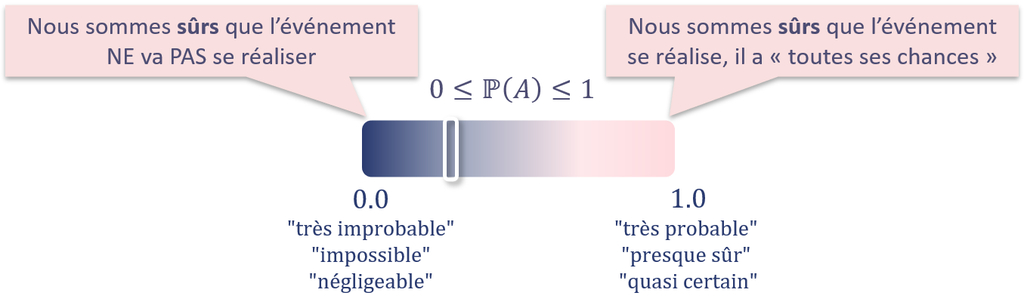

Notons ici que contrairement à la notion du risque et de la chance dans la vie quotidienne, où on opère souvent avec des pourcentages, lors de cours nous allons privilégier l’utilisation de la plage de valeur entre 0 et 1.

# Evénement, tribu, espace probabiliste

Les notions liées à celle de la probabilité nous aident à modéliser d’une manière abstraite des quantités mesurées et les comportements aléatoires souvent dans le but prédictif.

Considérons un dé cubique à 6 faces parfaitement équilibré 🎲.

L’issue (le résultat) de lancer d’un dé cubique parfaitement équilibré ne peut pas être prévu, il est du au hasard. Dans un cas pareil, on parle d’une *expérience aléatoire*.

Une **expérience aléatoire** (en. *experiment*) est une expérience renouvelable, dont le résultat est aléatoire (c’est-à-dire imprévisible) et qui, reproduite dans des conditions identiques, ne donne pas forcément le même résultat à chaque renouovellement de l’expérience.

Les exemples typiques sont : le lancement successif d’une même pièce, d’un dé, le tirage au hasard d’une carte, etc.

Reprenons l’exemple du lancement d’un dé.

**Quels sont les résultats (issues) posssibles d’une expérience ?**

Les résultats possibles sont : ⚀ ⚁ ⚂ ⚃ ⚄ ⚅. De point de vue mathématique, on peut réécrire cela de la façon suivante :

$$\Omega = \{1,2,3,4,5,6\}$$

Un **ensemble des possibles** ou **ensemble des éventualités** ou **univers des possibles** (en. *sample space* ou *possibility space*) est un ensemble de **tous** les issues / résultats (en. *outcomes*) possibles que l’on pourrait obtenir en réalisant une expérience aléatoire.

En utilisant les diagrammes de Venn, on peut présenter $\Omega$ comme suit :

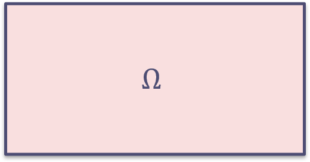

Voici quelques exemples des univers : $\Omega = \{pile, face\}$ pour le lancer de pièce, pour le tirage de carte dans un jeu de carte classique de 52 cartes $\Omega = \{coeur, pique, carreau, trèfle\} \times \{2, 3, 4, 5, 6, 7, 8, 9, 10, J, Q, K, A\}$ donné comme le produit cartésien de deux ensembles : couleurs et valeurs (rangs).

L’univers $\Omega$ peut être *discret* (fini et/ou denombrable) et *non discret*. Dans le cas d’un univers fini, on peut présenter $\Omega$ comme : $\Omega = \{\omega_1, \omega_2, ..., \omega_n \}, n\in \mathbb{N}$. Dans le cas d’un univers infini dénombrable : $\Omega = \{\omega_1, \omega_2, ...\}$.

Un exemple de l’univers qui n’est pas discret peut être $\Omega = (-\infty, +\infty)$.

Un **évènement élémentaire** ou **issue élémentaire** (en. *elementary event* ou *atomic event* ou *sample point*) est un ensemble $\{\omega\}$ constitué d’un seul élément de l’univers $\omega \in \Omega$ (un singleton).

Notons aussi que les issues possibles de l’expérience sont repésentée d’une manière unique.

Dans le cas de lancer d’un dé, un exemple d’un évènement élémentaire peut être $\{2\}$ ou $\{5\}$, etc. Pour le lancer de deux pièces, ça peut être $\{PP\}$ ou $\{PF\}$ où $P$ correspond à pile, et $F$ correspond à face. Dans le cas non discret, un exemple d’un évènement élémentaire peut être tous les ensemble $\{x\}, x\in \mathbb{R}$ de l’univers $\Omega = (-\infty, +\infty)$.

**Quelle proposition on cherche à vérifier à l’aide de l’expérience aléatoire ?**

On parle d’un *évènement* lié à une expérience aléatoire.

Un **évènement** $A$ (en. *event*) est un sous-ensemble des résultats possibles $\Omega$ d’une expérience aléatoire qui donc regroupe les évènements élémentaires (éventualités) pour lesquelles une certaine propriété est vérifiée. Ainsi, un évènement forme *les résultats favorables*.

Un ensemble de tous les évènements liés à l’éxpérience aléatoire, noté $\mathcal{A}$, possède une structure de tribu sur $\Omega$ aussi appelé $\sigma$-algèbre (en. $\sigma$-*algebra* ou $\sigma$-*field*) telle que :

- $\Omega \in \mathcal{A}$
- $\emptyset \in \mathcal{A}$
- stable par complémentaire : si $A\in \mathcal{A}$, alors $\bar{A} =(\Omega \setminus A)\in \mathcal{A}$
- stable par union dénombrable : si $A_i \in \mathcal{A}, \forall i \in \mathbb{N}$, alors $\left(\bigcup_{i=1}^n A_i \right) \in \mathcal{A}$
- stable par intersection dénombrable : si $A_i \in \mathcal{A}, \forall i \in \mathbb{N}$, alors $\left(\bigcap_{i=1}^n A_i \right) \in \mathcal{A}$

Un évènement $A \in \mathcal{A}$. Notons aussi que souvent un évènement est formulé par une proposition en langue naturelle (en intention).

De point de vue des évènements, on appelle $\Omega$ **l’évènement certain**, car il regroupe tous les issues possibles.

Comme le contraire de $\Omega$, on peut considérer l’ensemble vide $\emptyset$, que dans ce contexte on appelle **l’évènement impossible**.

Dans le cas de l’univers discret comme celui de lancer d’un dé, on peut définir $\mathcal{A}$ comme le superset de $\Omega$, i.e. $\mathcal{A} = \mathcal{P}(\Omega) = \{\emptyset, \{1\}, \{2\}, ..., \{6\},\{1,2\},..., \{1,6\},\{1,2,3\},...,\{2,3,4,5,6\}, \Omega\}$.

Dans le cas de l’univers continu, il ne s’agit plus de powerset. C’est à travers la notion de tribu $\mathcal{A}$ sur $\Omega$ qu’on restreint les évènements pour lequels on peut définir la mesure de probabilité.

Selon le résultat obtenu lors de l’expérience, l’évènement en question peut être **réalisé** ou pas.

**Exemple :** Reprenons l’exemple de lancer d’un dé. Pour rappel, $\Omega = \big\{$⚀,⚁,⚂,⚃,⚄,⚅$\big\}$ ou bien $\Omega = \{1,2,3,4,5,6\}$.

Supposons que l’évènement qui nous intéresse est donné par “*obtenir un résultat impair*”. Nous pouvons donc le réécrire de la façon suivante : $A = ``\text{obtenir un résultat impair}" = \{1,3,5\}$.

Considérons deux résultats d’expérience : $2$ et $3$ :

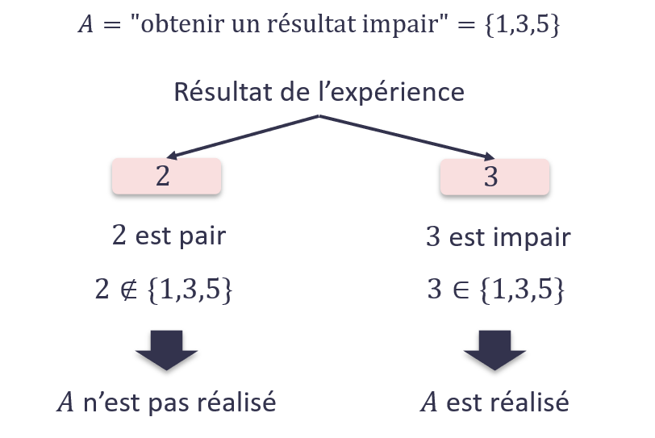

On peut voir que d’un côté on peut vérifier la propriété du nombre impair en partant de l’intention de l’évènement (approche en intention). De l’autre côté, on peut suivre l’approche ensembliste et vérifier si le résultat obtenu appartient ou pas à l’ensemble de résultats favorables.

On peut représenter l’évènement $A$ sous forme de diagramme de Venn de la façon suivante :

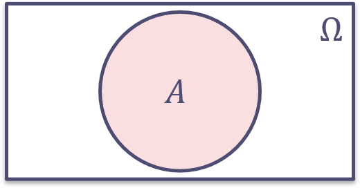

# Probabilité d’un évènement

Un **espace probabilisé** $(\Omega, \mathcal{A})$ (en. *measurable space*) est un espace mesurable, composé par un couple $(\Omega, \mathcal{A})$ où $\Omega$ est un ensemble et $\mathcal{A}$ une tribu sur $\Omega$.

Un espace probabilisé $(\Omega, \mathcal{A})$ complété d’une mesure $\mathbb{P}$ est appelé un **espace probabiliste** $(\Omega, \mathcal{A}, \mathbb{P})$ (en. *probability space* ou *probability triple*), si $\mathbb{P}$ est une mesure de probabilité telle que $\mathbb{P}(\Omega) = 1$.

Une **mesure de probabilité** (en. *probability measure*) $\mathbb{P}$ est une fonction réelle à valeurs dans l’intervalle unité $[0,1]$ (*positivité*) définie sur un espace d’évènements $\mathcal{A}$ dans l’espace probabiliste $(\Omega, \mathcal{A}, \mathbb{P})$ qui satisfait les propriétés de mesure :

- $\forall A\in \mathcal{A}, \mathbb{P}(A)\in [0,1]$
- $\mathbb{P}(\emptyset) = 0$
- $\mathbb{P}(\Omega) = 1$ (*masse unitaire*)
- propriété de $\sigma$-additivité : pour toute collection dénombrable $\forall \{A_i\}, i\in I$ (où $I \subset \mathbb{N}$ est un ensemble d’indices), $A_1, A_2, ... \in \mathcal{A}$ telle que $\forall i, j, i\neq j, A_i \cap A_j = \emptyset$ (*ensembles disjoints deux à deux* ou *ensembles mutuellement disjoints*), la propriété suivante est vérifiée :

$$\mathbb{P}\left(\bigcup_{i\in I}A_i\right) = \sum_{i\in I}\mathbb{P}(A_i)$$

Dans le cas où $\Omega = \{\omega_i\}_{i=1,...,n}$ est un univers fini et toutes les issues $\omega_i$ sont *équiprobables*, i.e. :
$$\mathbb{P}(\omega_1) = \mathbb{P}(\omega_2) = ... = \mathbb{P}(\omega_n) = \frac{1}{n}$$

la probabilité $\mathbb{P}$ est appelé **probabilité uniforme** sur $\Omega$.

Selon l’approche ensembliste, on peut considérer que $\forall A\in \mathcal{A}$ :
$$\mathbb{P}(A) = \frac{\text{\# résultats favorables}}{\text{\# résultats possibles}} = \frac{card(A)}{card(\Omega)}$$
où $card(\cdot)$ désigne la cordinalité de l’ensemble $\cdot$.

**Remarque :** notons que dans le cas d’un univers $\Omega$ infini (e.g. $\Omega = \mathbb{R}$ ou $\Omega = \mathbb{N}$), il est impossible d’associer à $(\Omega, \mathcal{A})$ la probabilité uniforme. Il ne s’agit donc plus d’équiprobabilité des issues, car cela impliquerait la non-conformité de $\mathbb{P}$ à la propriété $\mathbb{P}(\Omega) = 1$ étant donné la positivité de la mesure de probabilité.

En tenant compte de ce rapport $\frac{card(A)}{card(\Omega)}$, on perçoit bien que $0\leq \mathbb{P}(A)\leq 1$.

**Exemple :** Reprenons l’exemple de lancer d’un dé et l’évènement $A = ``\text{obtenir un résultat impair}" = \{1,3,5\}$. Calculons la probabilité de l’évènement $A$ :

$$\mathbb{P}(A) = \frac{\text{\# résultats favorables}}{\text{\# résultats possibles}} = \frac{card(A)}{card(\Omega)} = \frac{card(\{1,3,5\})}{card(\{1,2,3,4,5,6\})} = \frac{3}{6} = 1/2$$

Quel est *l’évènement contraire* à $A$ ou autrement dit, *l’évènement complémentaire* ?

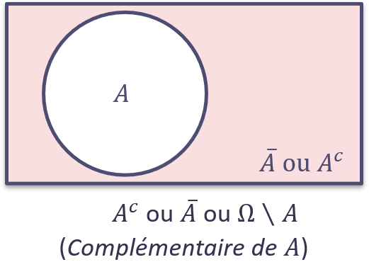

$\bar{A} = ``\text{"ne pas obtenir de résultat impair}" = \{2,4,6\}$

Calculons la probabilité de $\bar{A}$ en appliquant la même formule que dans le cas précédent :

$$\mathbb{P}(\bar{A}) = \frac{\text{\# résultats favorables}}{\text{\# résultats possibles}} = \frac{card(\bar{A})}{card(\Omega)} = \frac{card(\{2,4,6\})}{card(\{1,2,3,4,5,6\})} = \frac{3}{6} = 1/2$$

On peut voir que :

$$\mathbb{P}(\Omega) = \frac{card(\Omega)}{card(\Omega)} = \mathbb{P}(A) + \mathbb{P}(\bar{A}) = 1$$

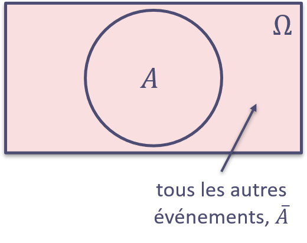

D’où :

$\mathbb{P}(A) = 1 - \mathbb{P}(\bar{A})$

## Exemple de calcul : vélos et trottinettes

Une station de vélo a 18 vélos de ville et 12 trottinettes électriques. Si nous choisissons 4 transports d’une manière aléatoire, quelle est la probabilité d’avoir 2 vélos de ville et 2 trottinettes ?

**Solution**

Définissons l’évènement : $A = ``\text{avoir 2 vélos et 2 trottinettes}"$

Le nombre total de transport à disposition à la station est : $18 + 12 = 30$.

On est dans le cas de l’univers fini. Alors, afin de calculer la probabilité de $A$, on peut se servir du rapport : $\mathbb{P}(A) = \frac{\text{\# résultats favorables}}{\text{\# résultats possibles}}$

##### Résultats possibles

Il s’agit de choisir 4 transports à partir de 30. Combien de choix possibles ?

Lorsque l’ordre n’a pas d’importance dans ce cas-là, il s’agit des combinaisons :

$$C_{30}^4 = \begin{pmatrix}30 \\ 4\end{pmatrix} = \frac{30!}{4!(30-4)!} = \frac{30!}{4!26!} = \frac{27\times 28\times 29\times 30}{4\times 3\times 2\times 1} = 27\times 7\times 29\times 5 = 27405$$
vérifions avec `R` :

```r
# choisir 4 parmi 30
choose(n=30, k=4)
```

```
## [1] 27405
```

##### Résultats favorables

Maintenant, on va calculer le nombre de résultats favorables en se basant sur le principe fondemantal de dénombrement. Pour cela, nous allons calculer :

- le nombre de façons de choisir 2 vélos à partir de 18 disponibles : $C_{18}^2 = \begin{pmatrix}18 \\ 2\end{pmatrix} =\frac{18!}{2!(18-2)!} = \frac{18!}{2!16!} = \frac{18\times 17}{2\times 1} = 153$
- le nombre de façons de choisir 2 trottinettes à partir de 12 : $C_{12}^2 = \begin{pmatrix}12 \\ 2\end{pmatrix} =\frac{12!}{2!(12-2)!} = \frac{12!}{2!10!} = \frac{12\times 11}{2\times 1} = 66$

et prendre leur produit : $\begin{pmatrix}18 \\ 2\end{pmatrix} \times \begin{pmatrix}12 \\ 2\end{pmatrix} = 153\times 66 = 10098$

vérifions avec `R`:

```r
# produit de 2 combinaisons : 2 à partir de 18 et 2 à partir de 18
choose(n=18, k=2)*choose(n=12, k=2)
```

```
## [1] 10098
```

##### Calcul final

Reprenons la formule de la probabilité de $A$ :

$$\mathbb{P}(A) = \frac{\text{\# résultats favorables}}{\text{\# résultats possibles}} = \frac{\begin{pmatrix}18 \\ 2\end{pmatrix} \times \begin{pmatrix}12 \\ 2\end{pmatrix}}{\begin{pmatrix}30 \\ 4\end{pmatrix}}= \frac{10098}{27405} \approx 0.368$$

Dans le `R` :

```r
# la probabilité finale
(choose(n=18, k=2)*choose(n=12, k=2))/choose(n=30, k=4)
```

```
## [1] 0.3684729
```

# Probabilité de deux évènements

Considérons maintenant deux évènements $A\in \mathcal{A}$ et $B\in \mathcal{A}$ d’un espace probabilisé $(\Omega, \mathcal{A}, \mathbb{P})$. Selon les relations entre $A$ et $B$, le calcul de la probabilité va se faire de façons différentes.

Reprenons l’exemple de lancer d’un dé. Pour rappel, $\Omega = \big\{$⚀,⚁,⚂,⚃,⚄,⚅$\big\}$ ou bien $\Omega = \{1,2,3,4,5,6\}$.

## $A$ et $B$

Soit $A = ``\text{obtenir un résultat pair}" = \{2,4,6\}$ et $B = ``\text{obtenir un résultats}\geq 4" = \{4,5,6\}$. Supposons que ce qu’on cherche est la probabilité d’avoir $A$ **et** $B$ réalisés.

De point de vue ensembliste, il s’agit de l’intersection de $A$ et $B$, $A\cap B = \{\omega|(\omega \in A) \&\& (\omega \in B) \}$ ou sous forme de diagramme de Venn :

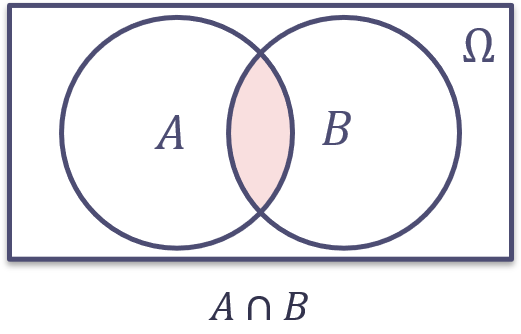

$A\cap B = \{2,\mathbf{4},\mathbf{6}\} \cap \{\mathbf{4},5,\mathbf{6}\} = \{4,6\} \neq \emptyset$

Alors : $\mathbb{P}(A\cap B) = \frac{card(A\cap B)}{card(\Omega)} = \frac{card(\{4,6\})}{card(\{1,2,3,4,5,6\})} = \frac{2}{6} = \frac{1}{3}$

$$\mathbb{P}(A\cap B) = \frac{card(A\cap B)}{card(\Omega)}$$

## $A$ ou $B$

Maintenant on va s’intéresser au cas de $A$ **ou** $B$. Deux options sont possibles :

1. $A$ et $B$ sont disjoints, i.e. $A\cap B = \emptyset$
2. $A\cap B \neq \emptyset$

#### 1. $\mathbb{P}(A\cup B)$ si $A\cap B = \emptyset$

Soit $A = ``\text{obtenir un résultat pair}" = \{2,4,6\}$ et $B = ``\text{obtenir un 3}" = \{3\}$.

Sous forme de diagramme de Venn, l’union de $A$ et $B$ où $A\cap B = \emptyset$ est donnée par :

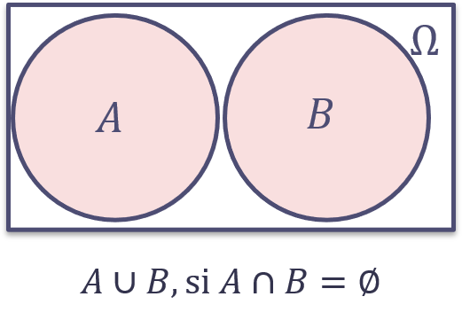

$A\cup B = \{2,4,6\} \cup \{3\} = \{2,3,4,6\}$

Alors : $\mathbb{P}(A\cup B) = \frac{card(A\cup B)}{card(\Omega)} = \frac{card(A) + card(B)}{card(\Omega)} = \mathbb{P}(A) + \mathbb{P}(B) = \frac{card(\{2,3,4,6\})}{card(\{1,2,3,4,5,6\})} = \frac{4}{6} = \frac{2}{3}$

Si $A\cap B = \emptyset$, alors :
$$\mathbb{P}(A\cup B) = \frac{card(A\cup B)}{card(\Omega)} = \frac{card(A) + card(B)}{card(\Omega)} = \mathbb{P}(A) + \mathbb{P}(B)$$

#### 2. $\mathbb{P}(A\cup B)$ si $A\cap B \neq \emptyset$

Soit $A = ``\text{obtenir un résultat pair}" = \{2,4,6\}$ et $B = ``\text{obtenir un 3 ou un 6}" = \{3, 6\}$.

Notons que dans ce cas là, $A\cap B = \{6\} \neq \emptyset$.

En terme de diagramme de Venn :

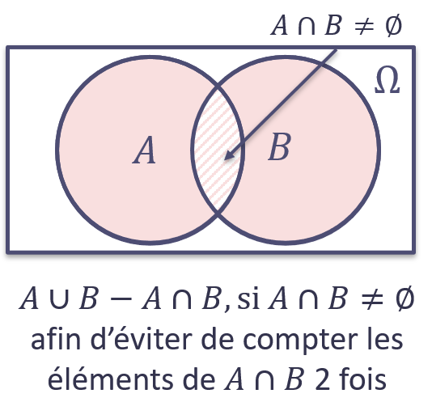

$A \cup B = \{2,4,6\} \cup \{3,6\} = \{2,3,4,\underbrace{\mathbf{6},\mathbf{6}}_{\text{doublon !}}\} = \{2,3,4,\mathbf{6}\}$

Notons qu’on ne garde qu’une seule instance de 6 dans l’ensemle obtenu car sinon on risque d’avoir les doublons. Dans ce cas là, $card(A\cup B)\neq card(A) + card(B)$.

Ainsi, afin d’éviter de compter les éléments de l’intersection $A\cap B$ deux fois, on va les enlever : $\mathbb{P}(A\cup B) =\frac{card(A\cup B)}{card(\Omega)}= \mathbb{P}(A) + \mathbb{P}(B) - \mathbb{P}(A\cap B) = \frac{3}{6} + \frac{2}{6} - \frac{1}{6} = \frac{4}{6} = \frac{2}{3}$

Pour $A\in \mathcal{A}$ et $B \in \mathcal{A}$ :
$$\mathbb{P}(A\cup B) = \mathbb{P}(A) + \mathbb{P}(B) - \mathbb{P}(A\cap B)$$

Notons que si $A\cap B = \emptyset$, alors $\mathbb{P}(A\cap B) = \mathbb{P}(\emptyset) = 0$. Donc, l’expression devient : $\mathbb{P}(A\cup B) = \mathbb{P}(A) + \mathbb{P}(B) - \mathbb{P}(A\cap B) = \mathbb{P}(A) + \mathbb{P}(B) - 0 = \mathbb{P}(A) + \mathbb{P}(B)$.

Cette propriété peut être généralisée pour le cas de $n$ évènements.

Notons que dans le cas de multiples évènements (ensembles), il faudra prendre en compte les intersections de toutes les combinaisons des ensembles.

Voici le digramme de Venn pour le cas de trois évènements :

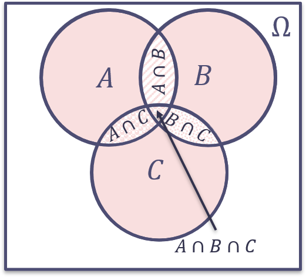

La formule générale est donc donné par :

Soit $A_1, A_2, ..., A_n\in \mathcal{A}$ :
$$\mathbb{P}\left(\bigcup_{i=1}^n A\right) = \sum_{i=1}^n \mathbb{P}(A_i) - \sum_{(i,j)|1\leq i<j\leq n} \mathbb{P}(A_i\cap A_j) + \sum_{(i,j,k)|1\leq i<j<k\leq n} \mathbb{P}(A_i\cap A_j \cap A_k) + ... +$$
$$+ (-1)^{n-1}\mathbb{P}(A_i\cap A_j \cap ... \cap A_n)$$
ou

$$\mathbb{P}\left(\bigcup_{i=1}^n A\right) = \sum_{k=1}^n (-1)^{k-1} \sum_{(i_1,...,i_k)|1\leq i_1 <...<i_k\leq n} \mathbb{P}(A_{i_1}\cap ...\cap A_{i_k})$$

## Exemple de calcul

Nous lançons un dé deux foix. L’univers est définit comme $\Omega = \{(i,j)\in \mathbb{N}^2, 1\leq i\leq 6, 1\leq j\leq 6\}$, $\mathcal{A} = \mathcal{P}(\Omega)$. Quelle est la probabilité que la somme des points soit 3 ou 4 ?

**Solution**

Décomposons l’évènement global $A' = ``\text{la somme des points soit 3 ou 4}"$ en 2 évènements séparés $A$ et $B$ définits comme suit :
$$\begin{matrix}
A = ``\text{la somme = 3}" \\
\mathbf{ou} \\
B = ``\text{la somme = 4}"
\end{matrix}$$

Remarquons que $A$ et $B$ sont disjoints, i.e. $A\cap B = \emptyset$ :

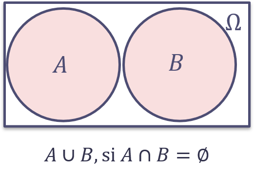

Donc,
$$\mathbb{P}(A\cup B) = \mathbb{P}(A) + \mathbb{P}(B) - \mathbb{P}(A\cap B) = \mathbb{P}(A) + \mathbb{P}(B) - 0 = \mathbb{P}(A) + \mathbb{P}(B)$$

Alors, la solution se restreint à la recherche de $\mathbb{P}(A)$ et $\mathbb{P}(B)$.

##### 1. $\mathbb{P}(A)$

Pour rappel, $A = ``\text{la somme = 3}"$. Regardons les cas où $A$ se réalise :

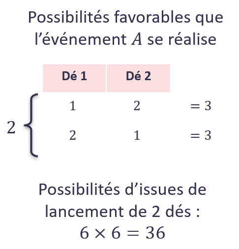

Il n’existe que 2 options pour que $A$ se réalise.

Le nombre total de résultats possibles est $6\times 6 = 36$ (le produit de 6 possibilités pour le 1er dé et 6 possibilités pour le 2ème dé).

$\mathbb{P}(A) = \frac{\text{\# résultats favorables}}{\text{\# résultats possibles}} = \frac{2}{36} = \frac{1}{18}$

##### 2. $\mathbb{P}(B)$

Pour rappel, $B = ``\text{la somme = 4}"$. Regardons les cas où $B$ se réalise :

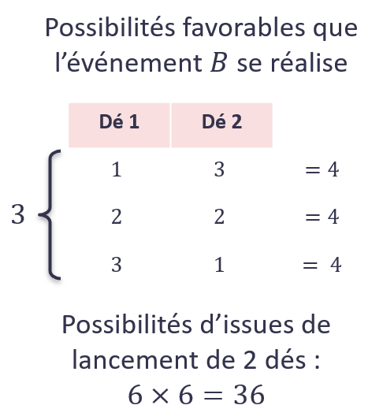

Il n’existe que 3 options pour que $B$ se réalise. Le nombre de résultats possibles reste le même, 36.

$\mathbb{P}(B) = \frac{\text{\# résultats favorables}}{\text{\# résultats possibles}} = \frac{3}{36} = \frac{1}{12}$

##### Calcul final

Reprenons la formule initiale :

$$\mathbb{P}(A\cup B) = \mathbb{P}(A) + \mathbb{P}(B) - \mathbb{P}(A\cap B) = \mathbb{P}(A) + \mathbb{P}(B) - 0 = \mathbb{P}(A) + \mathbb{P}(B) = \frac{2}{36} + \frac{3}{36} = \frac{5}{36}$$

# Probabilités conditionnelles et Indépendance

Dans la section précédente, nous avons vu le traitement de l’union et l’intersection de deux évènements.

Ainsi, dans le cas de l’union de $A\in \mathcal{A}$ et $B\in \mathcal{A}$ quand il s’agit de la réalisation de $A$ **ou** $B$, on a vu que $\mathbb{P}(A\cup B) = \mathbb{P}(A) + \mathbb{P}(B) - \mathbb{P}(A\cap B)$. On peut en déduire que $\mathbb{P}(A\cup B) \geq \mathbb{P}(A)$ et $\mathbb{P}(A\cup B)\geq \mathbb{P}(B)$.

Cepandant, nous avons moins traité le cas de l’intersection. En suivant l’intuition, on peut dire que $\mathbb{P}(A\cap B) < \mathbb{P}(A)$ et $\mathbb{P}(A\cap B) < \mathbb{P}(B)$. Quelle serait l’opération sur les probabilités individuelles de $A$ et $B$ qui pourrait assurer ces conditions, en tenant compte que $\mathbb{P}(A) \leq 1$ et $\mathbb{P}(B) \leq 1$ ?

Un bon candidat est le produit. Pour cela, on introduit ici la notion de **la probabilité de $B$ sachant $A$**, notée $\mathbb{P}(B|A)$. Ce qui peut être traduit par le fait que la réalisation de $A$ influence la probabilité de réalisation de $B$.

Résumons avec le schéma ci-dessous :

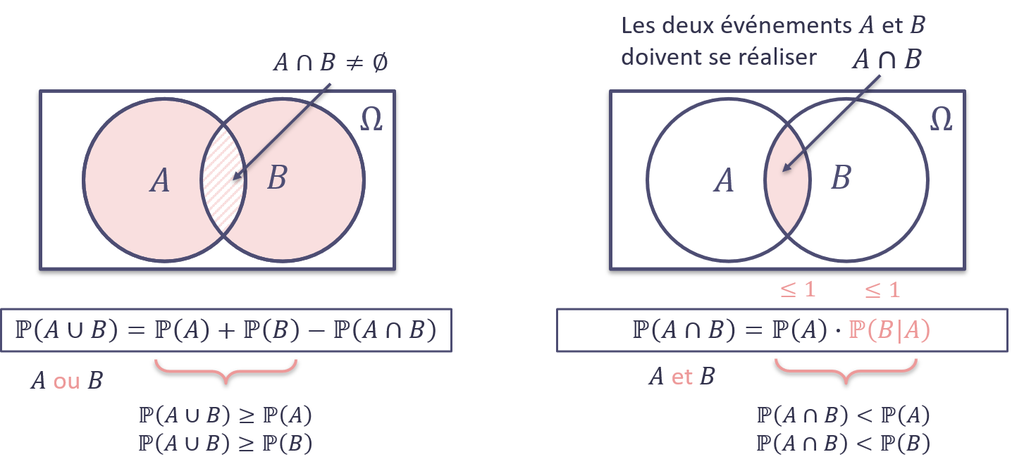

**Exemple :** Soit $A = ``\text{avoir un as}"$ et $B = ``\text{avoir un roi}"$, étant donné un jeu de 52 cartes. On cherche $\mathbb{P}(A\cap B)$.

Il y a 4 as dans le jeu de 52 cartes. La probabilité de réalisation de $A$ est alors donnée par : $\mathbb{P}(A) = \frac{\text{\# résultats favorables}}{\text{\# résultats possibles}} = \frac{4}{52}$.

Une fois $A$ est réalisé, le tirage d’une carte à partir de 52 est fait. Donc, il n’en reste que 51 pour les prochains tirages. Ainsi, **la réalisation de $A$ a influencé la réalisation de $B$**. Autrement dit, l’univers pour l’évènement $B$ est modifié.

Il y a 4 rois dans le jeu de 52 cartes. La probabilité de réalisation, de $B$ sachant que $A$ est réalisé implique le choix parmi les 51 cartes restantes, donc : $\mathbb{P}(B|A) = \frac{4}{51}$ ce qui est différent de $\mathbb{P}(B) = \frac{4}{52}$.

Dans ce cas là, on appelle les évènements $A$ et $B$ **dépendants**.

$$\mathbb{P}(A\cap B) = \mathbb{P}(A)\cdot \mathbb{P}(B|A) = \frac{4}{52}\cdot \frac{4}{51} \approx 0.006$$

Ainsi on cherche à calculer la probabilité de réalisation d’un évènement alors qu’une partie de l’information concernant le résultat est connue.

Soit $(\Omega, \mathcal{A}, \mathbb{P})$ un espace probabilisé, $A\in \mathcal{A}$, $B\in \mathcal{A}$ des évènements, $\mathbb{P}(B)\neq 0$. On appelle **la probabilité de $A$ sachant $B$** la probabilité définie par :
$$\mathbb{P}(A|B) = \frac{\mathbb{P}(A\cap B)}{\mathbb{P}(B)}$$
Si $\mathbb{P}(B) = 0$, on peut généraliser la définition pour le cas des évènements de probabilité nulle, i.e. $\mathbb{P}(A|B) = 0$.

**La probabilité conditionnelle sachant $B$** (en. *conditional probability*) est une application :
$$\mathbb{P}_B : A\in \mathcal{A} \rightarrow \mathbb{P}(A|B)$$
qui définit une probabilité sur l’espace des évènements $(\Omega, \mathcal{A})$.

Voici quelques propriétés de la probabilité conditionnelle sachant $B$:

1. $\mathbb{P}(\bar{A}|B) = 1 - \mathbb{P}(A|B)$ car on peut représenter $B$ comme $B = (B\cap A) \cup (B\cap \bar{A})$ où $(B\cap A) \cap (B\cap \bar{A}) = \emptyset$

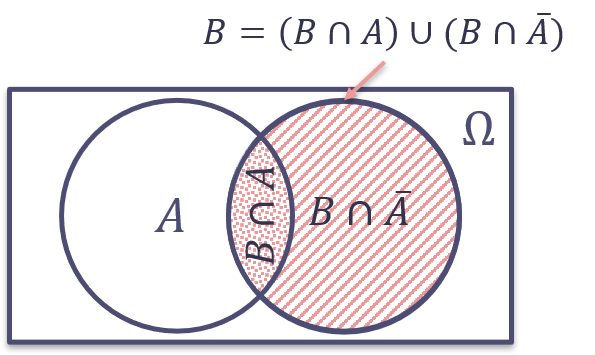

2. $\mathbb{P}(A\cap B) = \mathbb{P}(A|B)\times \mathbb{P}(B) = \mathbb{P}(B|A)\times \mathbb{P}(A)$

**Exemple :** Considérons maintenant lancer d’une pièce. Soit $A = ``\text{obtenir pile en lançant une pièce}"$ et $B = ``\text{obtenir face en lançant une pièce}"$.

$\mathbb{P}(A) = 1/2$. Notons que la réalisation de $A$ dans ce cas là n’influence pas la réalisation de $B$. Donc $\mathbb{P}(B|A) = \mathbb{P}(B) = 1/2$.

On parle des évènements **indépendants**.

Soit $(\Omega, \mathcal{A}, \mathbb{P})$ un espace probabilisé, $A, B \in \mathcal{A}$ deux évènements. $A$ et $B$ sont appelés **indépendants** (en. *independent events*), si :
$$\mathbb{P}(A\cap B) = \mathbb{P}(A)\times \mathbb{P}(B)$$
En utilisant la notion de la probabilité conditionnelle, on peut considérer que $A$ et $B$ tel que $\mathbb{P}(B)\neq 0$ sont indépendants si :
$$\mathbb{P}(A|B) = \mathbb{P}(A)$$

Notons que si les évènements $A$ et $B$ sont indépendants, alors les couples d’évènements suivants sont indépendants :

- $A$ et $\bar{B}$
- $\bar{A}$ et $B$
- $\bar{A}$ et $\bar{B}$

Les événements $A_1, ..., A_n\in \mathcal{A}$ dans l’espace probabilisé $(\Omega, \mathcal{A}, \mathbb{P})$ sont **mutuellement indépendants**, si $\forall k\in \{1,...,n\}$ et $\forall (i_1,...,i_k) \in \mathcal{N}^k\}$ tel que $1\leq i_1 \leq i_2\leq ...\leq i_k \leq n$, on a :
$$\mathbb{P}(A_{i_1} \cap ... \cap A_{i_k} ) = \mathbb{P}(A_{i_1})\times ... \times \mathbb{P}(A_{i_k})$$

Notons que pour le cas de 3 événements $A, B, C \in \mathcal{A}$, les conditions suivantes doivent être satisfaites :

1.indépendance 2 à 2 :

- $\mathbb{P}(A \cap B) = \mathbb{P}(A)\times \mathbb{P}(B)$
- $\mathbb{P}(A \cap C) = \mathbb{P}(A)\times \mathbb{P}(C)$
- $\mathbb{P}(B \cap C) = \mathbb{P}(B)\times \mathbb{P}(C)$
2. $\mathbb{P}(A \cap B \cap C) = \mathbb{P}(A)\times \mathbb{P}(B) \times \mathbb{P}(C)$

*Remarque* : des événements peuvent être 2 à 2 indépendants sans être mutuellement indépendants

## Examples de calcul

### Example 1

Si votre anniversaire est le 2 février, quelle est la probabilité que vos 2 amis ont leur anniversaire le même jour ?

**Solution**

Définissons les évènements $A$ et $B$ comme suit :

$A = ``\text{l'anniversaire d'un ami est le 2 fèvrier}"$ **et** $B = ``\text{l'anniversaire d'un autre ami est le 2 février}"$. On cherche la probabilité $\mathbb{P}(A\cap B)$.

On sait que $\mathbb{P}(A\cap B) = \mathbb{P}(A)\times \mathbb{P}(B|A)$. La question qui se pose est donc : est-ce que les évènements $A$ et $B$ sont indépendants ? autrement dit, est-ce que la réalisation de $A$ influence la réalisation de $B$ ?

Dans le cas général, la naissance d’un ami à un jour particulier n’infuence pas le jour de naissance d’un autre ami. Alors, $\mathbb{P}(B|A) = \mathbb{P}(B)$.

Trouvons les probabilités de $A$ et $B$, en considérans qu’une année contient 365 jours :

- $\mathbb{P}(A) = \frac{1}{365}$
- $\mathbb{P}(B) = \frac{1}{365}$

Reprenons la formule :

$\mathbb{P}(A\cap B) = \mathbb{P}(A)\times \mathbb{P}(B|A) = \mathbb{P}(A)\times \mathbb{P}(B) = \frac{1}{365}\times \frac{1}{365} = \mathbf{\frac{1}{365^2}}$

### Example 2

Karine, Michel, Kevin, Amélie, Pierre se connectent sur la session ZOOM de la Théorie des Probabilités aux moments différents et d’une manière aléatoire. Quelle est la probabilité que Karine se connecte la première et Kevin le dernier ?

**Solution**

L’ordre de connexion compte et une fois qu’une personne soit connectée, le nombre de possibilités pour les autres devient différent. Donc, il s’agit des événements dépendants.

Définissons les évènements $A$ et $B$ :

- $A = ``\text{Karine se connecte la 1ère}"$
- $B = ``\text{Kevin se connecte le dernier}"$

On cherche la probabilité $\mathbb{P}(A\cap B)$.

En utilisant la formule, nous savons que : $\mathbb{P}(A\cap B) = \mathbb{P}(A)\times \mathbb{P}(B|A)$.

Lorsqu’il y a 5 personnes, la probabilité de $A$, $\mathbb{P}(A) = \frac{\text{\# résultats favorables}}{\text{\# résultats possibles}} = \frac{1}{5}$.

Une fois Karine est connectée, il ne reste que quatre ``places". Ce qui nous intéresse c’est la dernière place. Donc $\mathbb{P}(B|A) = \frac{1}{4}$.

Alors, $\mathbb{P}(A\cap B) = \mathbb{P}(A)\times \mathbb{P}(B|A) = \frac{1}{5} \times \frac{1}{4} = \mathbf{\frac{1}{20}}$.

### Example 3

La probabilité de l’événement $A$ est $\mathbb{P}(A) = 0.8$, la probabilité de l’événement $C$ est $\mathbb{P}(C) = 0.35$ et la probabilité $\mathbb{P}(A\cap C) = 0.28$. Est-ce que les événements $A$ et $C$ sont indépendants ?

**Solution**

Les évènements $A$ et $C$ sont indépendants si $\mathbb{P}(A\cap C) = \mathbb{P}(A)\times \mathbb{P}(C)$.

On connaît $\mathbb{P}(A\cap C) = 0.28$. Il reste de calculer le produit : $\mathbb{P}(A)\times \mathbb{P}(C) = 0.8\times 0.35 = 0.28$.

Donc, on a vérifié que $0.28 = \mathbb{P}(A\cap C) = \mathbb{P}(A)\times \mathbb{P}(C) = 0.8\times 0.35 = 0.28$. Alors, les évènements $A$ et $C$ sont indépendants.

# Téorème bayesien (Bayes Rule)

Considérons un example suivant (les données sont imaginaires).

**Example :** La production de l’énergie d’un pays se base sur 3 sources principales. Le nucléaire produit 60% de l’énergie, les énergies fossiles 30% et les énergies renouvelables constituent 10%. Dans le premier cas, le processus de la production est complétement fonctionnelle dans 95% de temps, dans le 2ème cas dans 80% de temps, et dans le 3ème cas dans 65% de temps. Quelle est la probabilité qu’en vous inscrivant au contrat, vous n’allez pas avoir de faille ?

Notons par $B_1, B_2, B_3$ les sources de l’énergie : nucléaire, énergies fossiles et énergies renouvelables, respectivement. Les probabilités de $B_1, B_2, B_3$ sont alors données selon l’énnoncé par $\mathbb{P}(B_1) = 0.6$, $\mathbb{P}(B_2) = 0.3$, $\mathbb{P}(B_3) = 0.1$. Notons par $A$ l’évènement $``\text{contrat avec le service sans interruption}"$

Abordons ce problème en utilisant un arbre de probabilité.

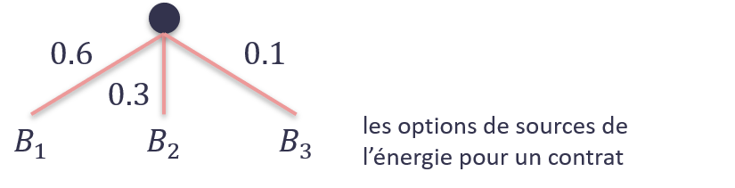

En sachant la provenance de l’énergie pour un contrat, on sait les probabilités de bon fonctionnement. Rajoutons cette information sur le diagramme :

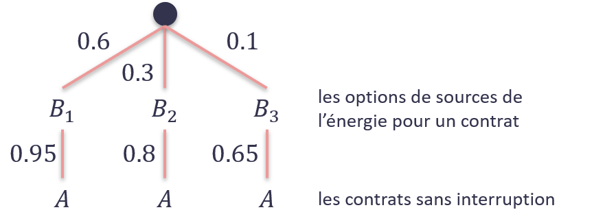

La deuxième partie de cet arbre correspond aux probabilités de $A$ en sachant $B_i, i=1,2,3$.

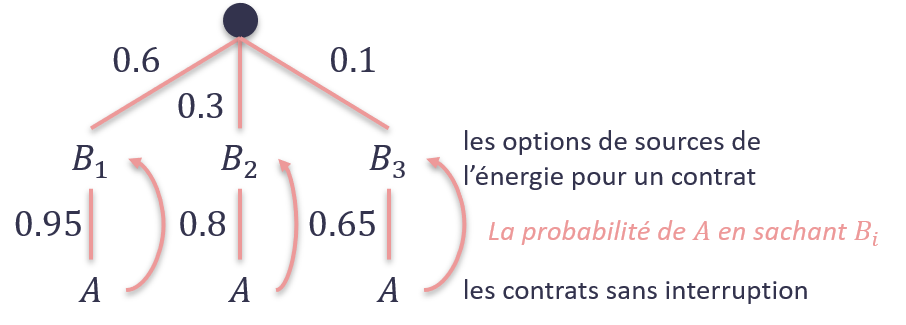

Ainsi, $\mathbb{P}(A|B_1) = 0.95$, $\mathbb{P}(A|B_2) = 0.8$, $\mathbb{P}(A|B_3) = 0.65$.

Remarquons qu’il existe 3 chemins différent pour arriver à $A$ :

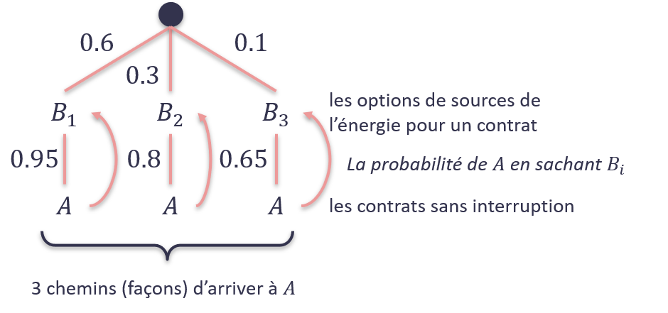

Alors, pour répondre à la question de l’ennoncé, il faut calculer $\mathbb{P}(A)$. Pour cela, on va se servir de tous ces chemins, i.e. :
$$\mathbb{P}(A) = \mathbb{P}(B_1)\cdot\mathbb{P}(A|B_1) + \mathbb{P}(B_2)\cdot\mathbb{P}(A|B_2) + \mathbb{P}(B_3)\cdot\mathbb{P}(A|B_3) =$$
$$= 0.6\times 0.95 + 0.3\times 0.8 + 0.1\times 0.65 = 0.57+0.24+0.065 = 0.875$$

**La formule des probabilités totales** (en. *law of total probability* ou *elimination rule*) : Soit $(\Omega, \mathcal{A}, \mathbb{P})$ un espace probabilisé. Soit $B_1, B_2, ..., B_n$ un système exhaustif d’évènements (partition de $\Omega$) tel que $\bigcup_{i=1}^n B_i = \Omega$ et $\forall (i,j)\in \{1,...,n\}^2, i\neq j, B_i \cap B_j = \emptyset$. Soit $\forall i=\overline{1,n}, \mathbb{P}(B_i)\neq 0$, alors
la probabilité totale de l’évènement $A \in \mathcal{A}$ est donné par :
$$\mathbb{P}(A) = \sum_{i=1}^n\mathbb{P}(A|B_i)\cdot \mathbb{P}(B_i) = \sum_{i=1}^n\mathbb{P}(A\cap B_i)$$

En reprenant le même example, imaginons que maintenant on s’intéresse à la probabilité de la source de l’énergie particulière sachant que $A$ s’est réalisé, autrement dit, on aimerait trouver $\mathbb{P}(B_i|A), i=1,2,3$.

Nous avons vu que la probabilité conditionnelle de $A$ sachant $B$ est donnée par : $\mathbb{P}(A|B) = \frac{\mathbb{P}(A\cap B)}{\mathbb{P}(B)}$. Alors, $\mathbb{P}(A\cap B) = \mathbb{P}(A|B)\times \mathbb{P}(B)$.

Considérons deux probabilités conditionnelles :

1. $\mathbb{P}(A|B) = \frac{\mathbb{P}(A\cap B)}{\mathbb{P}(B)} \Rightarrow \mathbb{P}(A\cap B) = \mathbb{P}(A|B)\times \mathbb{P}(B)$
2. $\mathbb{P}(B|A) = \frac{\mathbb{P}(B\cap A)}{\mathbb{P}(A)}$

Remplaçons $\mathbb{P}(B\cap A)$ par l’expression $\mathbb{P}(B\cap A) = \mathbb{P}(A|B)\times \mathbb{P}(B)$ dans la deuxième expression. Nous obtenons :

$$\mathbb{P}(B|A) = \frac{\mathbb{P}(B\cap A)}{\mathbb{P}(A)} = \frac{\mathbb{P}(A|B)\times \mathbb{P}(B)}{\mathbb{P}(A)}$$

On appelle cette formule **le théorème bayesien** ou **la formule de Bayes**.

**La formule de Bayes** (en. *Bayes rule*):

Soit $(\Omega, \mathcal{A}, \mathbb{P})$ un espace probabilisé. Soit $B_1, B_2, ..., B_n$ un système exhaustif d’évènements (partition de $\Omega$) tel que $\bigcup_{i=1}^n B_i = \Omega$ et $\forall (i,j)\in \{1,...,n\}^2, i\neq j, B_i \cap B_j = \emptyset$. Soit $\forall i=\overline{1,n}, \mathbb{P}(B_i)\neq 0$. Alors :

$$\forall A\in \mathcal{A}:\ \ \mathbb{P}(B_k|A) = \frac{\mathbb{P}(A|B_k)\times \mathbb{P}(B_k)}{\sum_{i=1}^n \mathbb{P}(A|B_i)\times \mathbb{P}(B_i)} = \frac{\mathbb{P}(A|B_k)\times \mathbb{P}(B_k)}{\mathbb{P}(A)}$$

# Liens utiles

1. Jeremy Orloff, and Jonathan Bloom. *18.05 Introduction to Probability and Statistics*. Spring 2014. Massachusetts Institute of Technology: MIT OpenCourseWare, https://ocw.mit.edu. License: Creative Commons BY-NC-SA.
2. Stéphane Balac, and Olivier Mazet. *Introduction aux Probabilités*. Centre de Mathématiques. Institut National des Sciences Appliquées de Lyon, https://perso.univ-rennes1.fr/stephane.balac/publis/polypbs.pdf
3. MathTutor. *Conditional Probability Tutorial*. https://www.youtube.com/watch?v=rp9I0x0jqHo